# Question

Consider the $L$-system (and angle) defined below:

- Start: `X`
- Rules:  
  `F > FF`  
  `X > F[+XXF+F][-XXF-F]FXX`
- Number of recursions (number of iterations):
  - 4
- Angle
  - 30°

Please use [this online tool](https://draemm.li/various/fractals/l-systems/) to generate the pattern using “turtle graphics”.

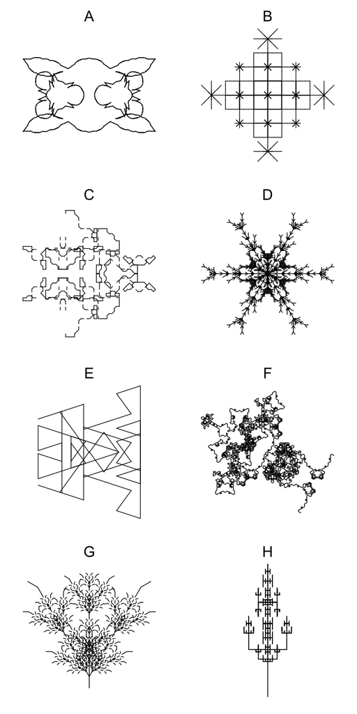

## Answerlist

- A
- B
- C
- D
- E
- F
- G
- H

# Solution

The correct pattern is pattern G.

1. Use the first link: https://draemm.li/various/fractals/l-systems/
2. Copy/paste the `Start`, `Rules`, `Angle`, and `Recursions`.
3. I usually start `Distance` at 1. It can be less than 1, like 0.1, if needed.
4. Click `Run!`
5. If necessary to make the pattern centered and scaled, adjust the `Start pos`, `Start angle`, and `Distance`.
6. Back to the quiz, select the matching pattern.

In case you’re interested in the parameters of the other patterns shown:

## Pattern A

- Start: `AA`
- Rules:  
  `A > A--ACB+C+BCA--A`  
  `B > BA+++C+++AB`  
  `C > -B--A+C+A--B-`
- Number of recursions (number of iterations):
  - 4
- Angle
  - 174

## Pattern B

- Start: `A`
- Rules:  
  `A > [----AAB][--AAB][++AAB]AAB`  
  `B > [-C][+C][--C][++C][---C][+++C]`  
  `C > CAB`
- Number of recursions (number of iterations):
  - 3
- Angle
  - 45

## Pattern C

- Start: `A`
- Rules:  
  `A > AXB+C+BXA`  
  `B > C--BAB--C`  
  `C > B+D-A-D+B`  
  `X > XX`  
  `D > DD`
- Number of recursions (number of iterations):
  - 4
- Angle
  - 45

## Pattern D

- Start: `A++++A++++A`
- Rules:  
  `A > [+BCC][-BCC]`  
  `B > B[-CA][+CA]`  
  `C > CCA`
- Number of recursions (number of iterations):
  - 5
- Angle
  - 30

## Pattern E

- Start: `A`
- Rules:  
  `A > +B-AA-B+`  
  `B > -A+BB+A-`
- Number of recursions (number of iterations):
  - 3
- Angle
  - 108

## Pattern F

- Start: `A`
- Rules:  
  `A > C--A++B++A--C`  
  `B > BA+C+AB`  
  `C > -B-CA+AC-B-`
- Number of recursions (number of iterations):
  - 5
- Angle
  - 60

## Pattern G

- Start: `X`
- Rules:  
  `F > FF`  
  `X > F[+XXF+F][-XXF-F]FXX`
- Number of recursions (number of iterations):
  - 4
- Angle
  - 30

## Pattern H

- Start: `A`
- Rules:  
  `A > CAA[--CAB][++CAB]`  
  `B > C[-CC-CA][+CC+CA]`  
  `C > CC`
- Number of recursions (number of iterations):
  - 5
- Angle
  - 90

# Meta-information

extype: schoice exsolution: 00000010 exname: lsys_pattern